# Latent Class and Rank Analysis

> **Note**: Some computationally intensive examples below are shown with `eval=FALSE` to keep CRAN build times short. For full rendered output, see the [pkgdown site](https://kosugitti.github.io/exametrika/articles/latent-class-rank.html).

```r
library(exametrika)
```

## Latent Class Analysis (LCA)

LCA classifies examinees into unordered latent classes. Specify the dataset and the number of classes.

```r
LCA(J15S500, ncls = 5)
```

```
#>
#> Item Reference Profile
#>          IRP1   IRP2   IRP3   IRP4  IRP5
#> Item01 0.5899 0.6616 0.7723 0.8528 0.884
#> Item02 0.5174 0.7102 0.8282 0.8863 0.871
#> Item03 0.5913 0.6112 0.8905 0.7196 0.839
#> Item04 0.3894 0.8671 0.8214 0.8657 1.000
#> Item05 0.6729 0.6759 1.0000 0.7718 0.920
#> Item06 0.6261 0.8857 0.9478 1.0000 0.903
#> Item07 0.3530 0.7209 0.7978 0.8818 0.891
#> Item08 0.3087 0.5911 0.5724 0.9172 0.609
#> Item09 0.2856 0.5414 0.2028 0.0993 0.692
#> Item10 0.5334 0.4995 0.8109 0.6898 0.800
#> Item11 0.0977 0.0203 0.0437 0.6450 0.678
#> Item12 0.0324 0.2904 0.1232 0.2821 0.684
#> Item13 0.2753 0.5690 0.9059 0.6655 0.811
#> Item14 0.4745 0.7017 0.7876 0.9101 1.000
#> Item15 0.4076 0.6879 0.8160 0.8471 0.824
#>
#> Test Profile
#>                               Class 1 Class 2 Class 3 Class 4 Class 5
#> Test Reference Profile          6.155   9.034  10.321  11.034  12.405
#> Latent Class Ditribution      119.000  90.000 112.000  86.000  93.000
#> Class Membership Distribution 112.597  99.086  98.336  93.200  96.780
#>
#> Item Fit Indices
#>        model_log_like bench_log_like null_log_like model_Chi_sq null_Chi_sq
#> Item01       -265.973       -240.190      -283.343       51.567      86.307
#> Item02       -252.897       -235.436      -278.949       34.922      87.025
#> Item03       -274.316       -260.906      -293.598       26.818      65.383
#> Item04       -197.016       -192.072      -265.962        9.889     147.780
#> Item05       -210.738       -206.537      -247.403        8.402      81.732
#> Item06       -160.728       -153.940      -198.817       13.576      89.755
#> Item07       -248.566       -228.379      -298.345       40.375     139.933
#> Item08       -295.140       -293.225      -338.789        3.829      91.127
#> Item09       -275.187       -300.492      -327.842      -50.611      54.700
#> Item10       -300.309       -288.198      -319.850       24.221      63.303
#> Item11       -184.967       -224.085      -299.265      -78.237     150.360
#> Item12       -228.339       -214.797      -293.598       27.085     157.603
#> Item13       -270.948       -262.031      -328.396       17.834     132.730
```

[output cut: 40 more lines]

```
#> bench_log_like -3560.005
#> null_log_like  -4350.217
#> model_Chi_sq     183.797
#> null_Chi_sq     1580.424
#> model_df         135.000
#> null_df          195.000
#> NFI                0.884
#> RFI                0.832
#> IFI                0.966
#> TLI                0.949
#> CFI                0.965
#> RMSEA              0.027
#> AIC              -86.203
#> CAIC            -790.175
#> BIC             -655.175
```

The Class Membership Matrix indicates which latent class each examinee belongs to:

```r
result.LCA <- LCA(J15S500, ncls = 5)
head(result.LCA$Students)
```

```
#>            Membership 1 Membership 2 Membership 3 Membership 4 Membership 5
#> Student001 0.7285244374  0.012211535  0.226232540 3.303149e-02 3.055593e-12
#> Student002 0.0220645036  0.086986302  0.830839343 6.010974e-02 1.074954e-07
#> Student003 0.0170578933  0.054109896  0.879752304 2.100872e-02 2.807118e-02
#> Student004 0.0010508039  0.223175413  0.203820488 3.286491e-01 2.433042e-01
#> Student005 0.9407961670  0.053321705  0.004873703 1.808344e-08 1.008407e-03
#> Student006 0.0002372397  0.002528968  0.029747250 8.551046e-01 1.123819e-01
#>            Estimate
#> Student001        1
#> Student002        3
#> Student003        3
#> Student004        4
#> Student005        1
#> Student006        4
```

### LCA Plot Types

- **IRP**: Item Reference Profile
- **CMP**: Class Membership Profile
- **TRP**: Test Reference Profile
- **LCD**: Latent Class Distribution

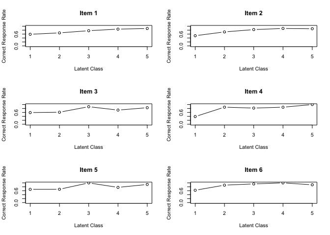

```r
plot(result.LCA, type = "IRP", items = 1:6, nc = 2, nr = 3)
```

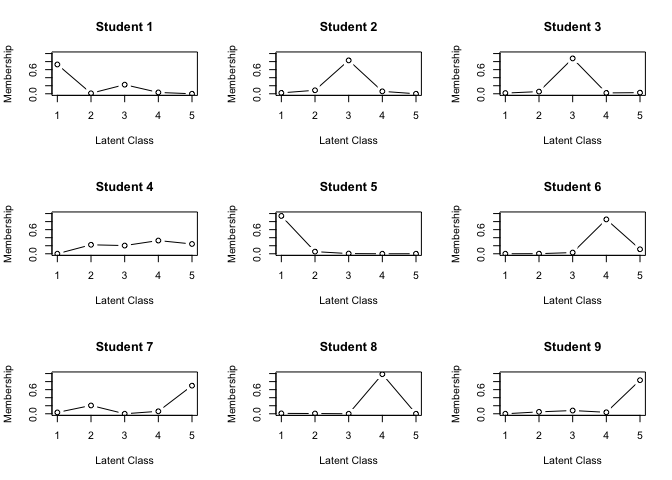

```r
plot(result.LCA, type = "CMP", students = 1:9, nc = 3, nr = 3)
```

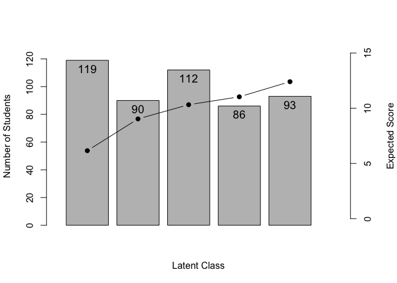

```r
plot(result.LCA, type = "TRP")
```

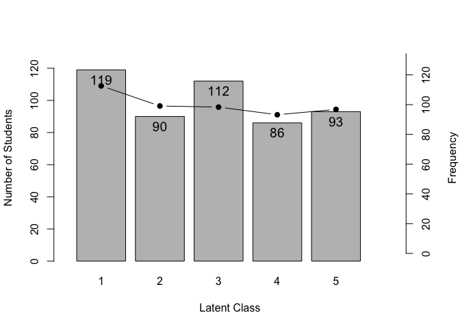

```r
plot(result.LCA, type = "LCD")
```

## Latent Rank Analysis (LRA)

LRA is similar to LCA but assumes an ordering among the latent classes (ranks). Specify the dataset and the number of ranks.

```r
LRA(J15S500, nrank = 6)
```

```
#> estimating method is  isotonic
#> Item Reference Profile
#>          IRP1   IRP2   IRP3   IRP4  IRP5  IRP6
#> Item01 0.4582 0.7484 0.7484 0.7484 0.839 0.914
#> Item02 0.5601 0.5601 0.8048 0.8048 0.883 0.883
#> Item03 0.5996 0.5996 0.7590 0.7590 0.759 0.866
#> Item04 0.4668 0.4668 0.8949 0.8949 0.895 0.995
#> Item05 0.5593 0.8284 0.8284 0.8284 0.828 0.936
#> Item06 0.6196 0.7691 0.9416 0.9416 0.942 0.942
#> Item07 0.4112 0.4112 0.7402 0.8959 0.896 0.896
#> Item08 0.3485 0.3485 0.6006 0.7315 0.732 0.732
#> Item09 0.3149 0.3149 0.3149 0.3149 0.315 0.619
#> Item10 0.4438 0.6344 0.6940 0.6940 0.722 0.765
#> Item11 0.0816 0.0816 0.0816 0.0816 0.688 0.688
#> Item12 0.0653 0.0653 0.2193 0.2193 0.219 0.859
#> Item13 0.2228 0.4902 0.7527 0.7527 0.753 0.788
#> Item14 0.2894 0.7760 0.7760 0.7760 0.933 1.000
#> Item15 0.3830 0.5188 0.8164 0.8164 0.816 0.845
#>
#> Item Reference Profile Indices
#>        Alpha     A Beta     B Gamma C
#> Item01     1 0.290    1 0.458     0 0
#> Item02     2 0.245    1 0.560     0 0
#> Item03     2 0.159    1 0.600     0 0
#> Item04     2 0.428    1 0.467     0 0
#> Item05     1 0.269    1 0.559     0 0
#> Item06     2 0.173    1 0.620     0 0
#> Item07     2 0.329    1 0.411     0 0
#> Item08     2 0.252    3 0.601     0 0
#> Item09     5 0.304    6 0.619     0 0
#> Item10     1 0.191    1 0.444     0 0
#> Item11     4 0.607    5 0.688     0 0
#> Item12     5 0.640    3 0.219     0 0
#> Item13     1 0.267    2 0.490     0 0
#> Item14     1 0.487    1 0.289     0 0
#> Item15     2 0.298    2 0.519     0 0
#>
#> Test Profile
#>                              Rank 1 Rank 2 Rank 3  Rank 4 Rank 5 Rank 6
#> Test Reference Profile        5.824  7.613  9.973  10.259 11.219 12.727
```

[output cut: 58 more lines]

```
#> bench_log_like -3560.005
#> null_log_like  -4350.217
#> model_Chi_sq     343.918
#> null_Chi_sq     1580.424
#> model_df         161.000
#> null_df          195.000
#> NFI                0.782
#> RFI                0.736
#> IFI                0.871
#> TLI                0.840
#> CFI                0.868
#> RMSEA              0.048
#> AIC               21.918
#> CAIC            -817.634
#> BIC             -656.634
```

Rank membership probabilities and rank-up/rank-down odds are calculated:

```r
result.LRA <- LRA(J15S500, nrank = 6)
head(result.LRA$Students)
```

```
#>            Membership 1 Membership 2 Membership 3 Membership 4 Membership 5
#> Student001 0.3732015798  0.428451221   0.11219848  0.030244910  0.055903805
#> Student002 0.0200254309  0.080848295   0.57928413  0.282874219  0.036967734
#> Student003 0.0062126694  0.213151690   0.54304200  0.146385733  0.076483260
#> Student004 0.0010041013  0.009115691   0.19880904  0.293017561  0.133718573
#> Student005 0.2529143262  0.727293364   0.01394516  0.003759143  0.001964068
#> Student006 0.0001300928  0.002053329   0.04593162  0.067696979  0.766760085
#>            Membership 6 Estimate Rank-Up Odds Rank-Down Odds
#> Student001 6.653884e-09        2   0.26186990     0.87104800
#> Student002 1.950328e-07        3   0.48831688     0.13956587
#> Student003 1.472465e-02        3   0.26956613     0.39251419
#> Student004 3.643350e-01        6           NA     0.36702090
#> Student005 1.239411e-04        2   0.01917405     0.34774733
#> Student006 1.174279e-01        5   0.15314816     0.08828965
```

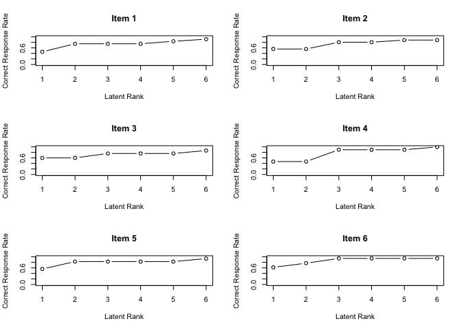

```r
plot(result.LRA, type = "IRP", items = 1:6, nc = 2, nr = 3)
```

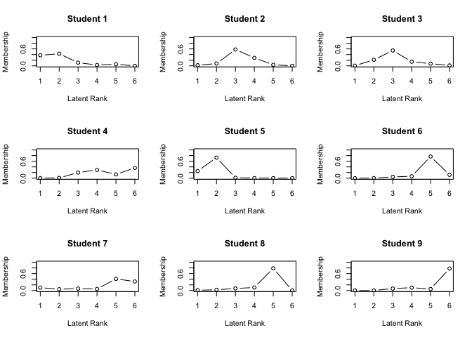

```r
plot(result.LRA, type = "RMP", students = 1:9, nc = 3, nr = 3)
```

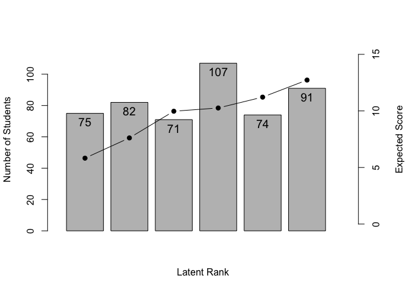

```r
plot(result.LRA, type = "TRP")
```

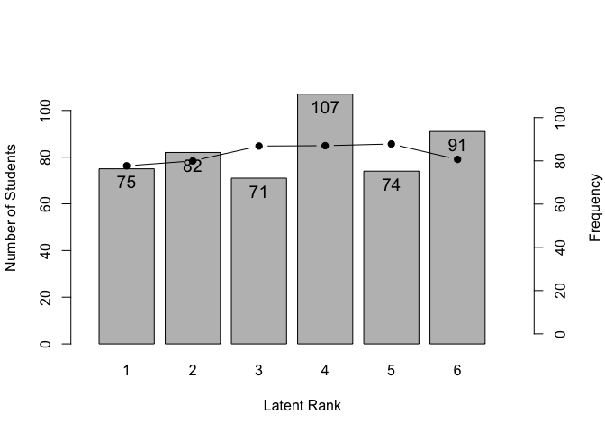

```r
plot(result.LRA, type = "LRD")
```

## LRA for Ordinal Data

LRA can also handle ordinal scale data. The `mic` option enforces monotonic increasing constraints.

```r
result.LRAord <- LRA(J15S3810, nrank = 3, mic = TRUE)
```

Score-rank relationship visualizations:

```r
plot(result.LRAord, type = "ScoreFreq")
plot(result.LRAord, type = "ScoreRank")
```

Item-rank relationship plots:

- **ICBR**: Item Category Boundary Reference – cumulative probability curves for each category threshold
- **ICRP**: Item Category Response Profile – probability of each response category across ranks

```r
plot(result.LRAord, type = "ICBR", items = 1:4, nc = 2, nr = 2)
plot(result.LRAord, type = "ICRP", items = 1:4, nc = 2, nr = 2)
```

Rank membership profiles for individual examinees:

```r
plot(result.LRAord, type = "RMP", students = 1:9, nc = 3, nr = 3)
```

## LRA for Rated/Nominal Data

For multiple-choice tests (nominal scale), LRA can analyze response patterns including distractor choices.

```r
result.LRArated <- LRA(J35S5000, nrank = 10, mic = TRUE)
```

```r
plot(result.LRArated, type = "ScoreFreq")
plot(result.LRArated, type = "ScoreRank")
```

```r
plot(result.LRArated, type = "ICRP", items = 1:4, nc = 2, nr = 2)
```

## Reference

Shojima, K. (2022). *Test Data Engineering*. Springer.